# Evaluation of Socio Demographic Results

This is the evaluation of the experiment’s socio demographic results. It expands the master thesis by data analysis and respective code as well as short explanations. This markdown does not replace the thesis, it serves solely as an appendix.

# Library Downloads

```r
library(tidyverse)
library(broom)
library(ggplot2)
library(dplyr)
```

# Sample Description: Socio Demographics

First, the final sample is loaded:

```r
getwd()
```

```
[1] "/Users/lara-aidajopp/Documents/Programming_Stuff/Universität Mannheim/Masterthesis/evaluation"
```

```r
raw_data <- readxl::read_excel("data/raw_data.xlsx", sheet = 2)
glimpse(raw_data)
```

```
Rows: 131
Columns: 27
$ `NEW CASE NR` <dbl> 1, 2, 3, 4, 5, 6, 7, 8, 9, 10, 11, 12, 13, 14, 15, 16, 17…
$ SD01          <dbl> 1, 2, 2, 1, 1, 1, 1, 2, 1, 1, 1, 2, 1, 1, 1, 1, 1, 1, 2, …
$ SD02          <dbl> 11, 2, 2, 5, 2, 8, 5, 2, 3, 4, 2, 2, 2, 1, 9, 8, 2, 2, 3,…
$ SD04          <dbl> 5, 7, 6, 11, 10, 6, 5, 10, 9, 11, 10, 9, 6, 1, 14, 7, 7, …
$ SD04_14       <chr> NA, NA, NA, NA, NA, NA, NA, NA, NA, NA, NA, NA, NA, NA, "…
$ SD05          <dbl> 7, 2, 6, 5, 4, 4, 4, 4, 6, 4, 4, 4, 2, 1, 4, 4, 3, 4, 4, …
$ TR01_CP       <dbl> 2, 2, 3, 3, 4, 4, 5, 5, 5, 6, 6, 6, 7, 8, 9, 10, 10, 11, …
$ TR01          <dbl> 3, 2, 1, 2, 2, 1, 4, 1, 3, 2, 4, 1, 1, 2, 4, 1, 2, 2, 1, …
$ AC01_01       <dbl> 5, 4, 5, 5, 5, 5, 4, 5, 4, 3, 4, 3, 5, 4, 5, 4, 2, 3, 3, …
$ AC01_02       <dbl> 5, 4, 5, 4, 5, 4, -1, 4, 4, 4, 4, 3, 4, 5, 4, -1, 5, 2, 4…
$ AC01_03       <dbl> 5, 4, 5, 4, 2, 5, 4, 5, 4, 4, 3, 3, 5, 4, -1, 5, 4, 3, 4,…
$ DI01_01       <dbl> 5, 2, 4, 4, 3, 5, 4, 4, -1, 5, 3, 3, 5, 5, -1, 5, 4, 3, 4…
$ DI01_02       <dbl> 5, 1, 1, 1, 1, 1, 5, -1, 5, -1, 4, 3, 5, 4, 4, 3, 1, 3, 1…
$ DI01_03       <dbl> 5, 1, 1, 1, 1, 1, 5, -1, 5, -1, 5, 3, 5, -1, 4, -1, 1, 4,…
$ DI01_04       <dbl> 5, 2, 1, 1, 1, 1, -1, -1, 4, 3, 4, 3, 5, 3, 4, -1, 4, 4, …
$ UI01_01       <dbl> 5, 4, 4, 5, 4, 5, 5, 5, 3, 5, 5, 3, 5, 5, 5, 5, 4, 3, 4, …
$ UI01_02       <dbl> 4, 5, 5, 5, 4, 5, 4, 5, 4, 5, 3, 3, 5, 5, 5, 5, 5, 3, 4, …
$ UI01_03       <dbl> 5, 3, -1, -1, 4, -1, -1, 4, 3, 5, 2, 3, 5, 5, -1, 4, 4, 4…
$ UI01_04       <dbl> 5, 2, 1, 1, 1, 1, -1, -1, 2, 1, 1, 3, 5, 2, 1, -1, 1, 4, …
$ EX01_01       <dbl> 5, 4, 3, 3, -1, 2, -1, 5, 4, 4, 4, 3, 5, 3, 5, 4, 2, -1, …
$ EX01_02       <dbl> 5, 2, 3, 1, 4, 2, -1, 2, 2, 2, 2, 3, 5, 5, 4, 3, 3, 3, 1,…
$ EX01_03       <dbl> 5, 1, 3, 1, -1, 2, -1, 2, 2, 1, 1, 3, 5, 3, 4, 3, 1, 4, 1…
$ EX01_04       <dbl> 5, 1, 1, 1, 1, 2, 4, 1, 4, -1, 4, 3, 4, 5, 4, -1, 1, 2, 1…
$ STARTED       <dttm> 2025-09-26 14:11:10, 2025-09-26 15:13:01, 2025-09-26 15:…
$ LASTDATA      <dttm> 2025-09-26 14:16:16, 2025-09-26 15:21:43, 2025-09-26 15:…
$ TIME_SUM      <dbl> 306, 430, 369, 555, 445, 309, 749, 318, 277, 959, 379, 87…
$ FINISHED      <dbl> 1, 1, 1, 1, 1, 1, 1, 1, 1, 1, 1, 1, 1, 1, 1, 1, 1, 1, 1, …
```

Out of the raw data, we can at least analyze the socio demographics of each participant. Each demographic information is grouped to evaluate its percentage in order to gain information about if the sample depicts the group of potential end users.

```r
socio_demographics <- raw_data[, c("SD01", "SD02", "SD04", "SD04_14", "SD05")]

socio_demographics <- rename(socio_demographics, sex = SD01, age_group_years = SD02, degree = SD04, degree_special = SD04_14, employment = SD05)

socio_demographics <- socio_demographics %>%
  mutate(
    sex = factor(sex,
                 labels = c("Female", "Male")),
)

glimpse(socio_demographics)
```

```
Rows: 131
Columns: 5
$ sex             <fct> Female, Male, Male, Female, Female, Female, Female, Mal…
$ age_group_years <dbl> 11, 2, 2, 5, 2, 8, 5, 2, 3, 4, 2, 2, 2, 1, 9, 8, 2, 2, …
$ degree          <dbl> 5, 7, 6, 11, 10, 6, 5, 10, 9, 11, 10, 9, 6, 1, 14, 7, 7…
$ degree_special  <chr> NA, NA, NA, NA, NA, NA, NA, NA, NA, NA, NA, NA, NA, NA,…
$ employment      <dbl> 7, 2, 6, 5, 4, 4, 4, 4, 6, 4, 4, 4, 2, 1, 4, 4, 3, 4, 4…
```

Based on that the share of sex is evaluated:

```r
sex <- socio_demographics %>%
  group_by(sex) %>%
  summarise(
    absolute_count = n()
  ) %>%
  mutate(relative_share_percent = round(100 * absolute_count / sum(absolute_count), 0)
  )

sex
```

| sex | absolute_count | relative_share_percent |
| --- | --- | --- |
| Female | 56 | 43 |
| Male | 75 | 57 |

Now, the age is evaluated and plotted using a bar plot showing the absolute count:

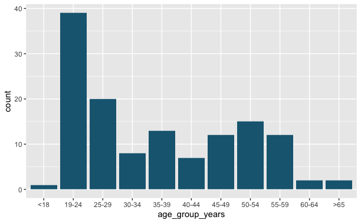

```r
age_group_labels <- c("<18", "19-24", "25-29", "30-34", "35-39", "40-44", "45-49", "50-54", "55-59", "60-64", ">65")

age <- socio_demographics %>%
  sort_by(socio_demographics$age_group_years) %>%
  mutate(age_group_years = factor(age_group_years, labels = age_group_labels))

ggplot(data = age, aes(x=age_group_years)) + geom_bar(fill=rgb(0.1,0.4,0.5,1))
```

The following shows the age group distribution in percentage:

```r
age_group_labels <- c("<18", "19-24", "25-29", "30-34", "35-39", "40-44", "45-49", "50-54", "55-59", "60-64", ">65")

age <- socio_demographics %>%
    sort_by(socio_demographics$age_group_years) %>%
  mutate(age_group_years = factor(age_group_years, labels = age_group_labels)) %>%
  group_by(age_group_years) %>%
  summarise(absolute_count = n()
  ) %>%
  mutate(relative_share_percent= round(100 * absolute_count / sum(absolute_count), 2))

print.data.frame(age)
```

```
   age_group_years absolute_count relative_share_percent
1              <18              1                   0.76
2            19-24             39                  29.77
3            25-29             20                  15.27
4            30-34              8                   6.11
5            35-39             13                   9.92
6            40-44              7                   5.34
7            45-49             12                   9.16
8            50-54             15                  11.45
9            55-59             12                   9.16
10           60-64              2                   1.53
11             >65              2                   1.53
```

The results display that the age groups are widely spread with an high concentration on the group of 19-24 yr olds (39, 29.77 %) followed by the group of 25-29 yr olds (20, 15.27 %) and on a third place, the 50-54 yr olds (15, 11.45 %). However, all age groups spanning from <18 yrs until >65 yrs have at least one representative.

Since the age group has been conducted, the degree is evaluated next:

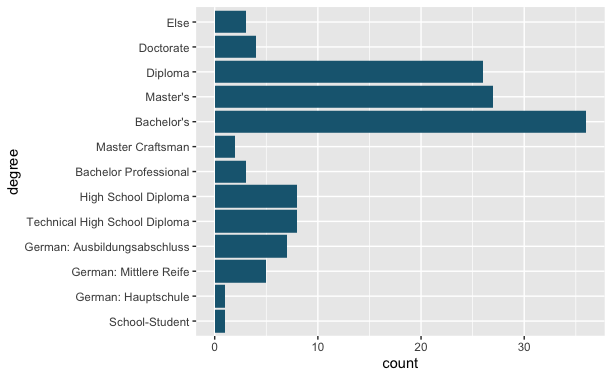

```r
degree_labels <- c("School-Student", "German: Hauptschule", "German: Mittlere Reife", "German: Ausbildungsabschluss", "Technical High School Diploma", "High School Diploma", "Bachelor Professional", "Master Craftsman", "Bachelor's", "Master's", "Diploma", "Doctorate", "Else")

degree <- socio_demographics %>%
  sort_by(socio_demographics$degree) %>%
  mutate(degree = factor(degree, labels = degree_labels))

ggplot(data = degree, aes(x=degree)) + geom_bar(fill=rgb(0.1,0.4,0.5,1)) +
coord_flip()
```

The following shows the degree distribution in percentage:

```r
degree_labels <- c("School-Student", "German: Hauptschule", "German: Mittlere Reife", "German: Ausbildungsabschluss", "Technical High School Diploma", "High School Diploma", "Bachelor Professional", "Master Craftsman", "Bachelor's", "Master's", "Diploma", "Doctorate", "Else")

degree <- socio_demographics %>%
    sort_by(socio_demographics$degree) %>%
  mutate(degree = factor(degree, labels = degree_labels)) %>%
  group_by(degree) %>%
  summarise(
    absolute_count = n(),
    degree_special = if (first(degree) == "Else") {
      paste(sort(degree_special), collapse = ", ")
    } else {
      ""
    }
  ) %>%
  mutate(relative_share_percent = round(100 * absolute_count / sum(absolute_count), 2))

print.data.frame(degree)
```

```
                          degree absolute_count
1                 School-Student              1
2            German: Hauptschule              1
3         German: Mittlere Reife              5
4   German: Ausbildungsabschluss              7
5  Technical High School Diploma              8
6            High School Diploma              8
7          Bachelor Professional              3
8               Master Craftsman              2
9                     Bachelor's             36
10                      Master's             27
11                       Diploma             26
12                     Doctorate              4
13                          Else              3
                                                                                  degree_special
1
2
3
4
5
6
7
8
9
10
11
12
13 Deutscher und Europäischer Qualifikationsrahmen, Niveau 4, Staatsexamen, Staatsexamen Medizin
   relative_share_percent
1                    0.76
2                    0.76
3                    3.82
4                    5.34
5                    6.11
6                    6.11
7                    2.29
8                    1.53
9                   27.48
10                  20.61
11                  19.85
12                   3.05
13                   2.29
```

Finally, the employment status is evaluated:

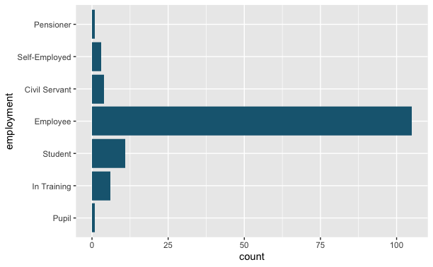

```r
employment_labels <- c("Pupil", "In Training", "Student", "Employee", "Civil Servant", "Self-Employed", "Pensioner")

employment <- socio_demographics %>%
  sort_by(socio_demographics$employment) %>%
  mutate(employment = factor(employment, labels = employment_labels))

ggplot(data = employment, aes(x=employment)) + geom_bar(fill=rgb(0.1,0.4,0.5,1)) + coord_flip()
```

The following shows the employment distribution in percentage:

```r
employment_labels <- c("Pupil", "In Training", "Student", "Employee", "Civil Servant", "Self-Employed", "Pensioner")

employment <- socio_demographics %>%
  sort_by(socio_demographics$employment) %>%
  mutate(employment = factor(employment, labels = employment_labels)) %>%
  group_by(employment) %>%
  summarise(absolute_count = n()
  ) %>%
  mutate(relative_share_percent= round(100 * absolute_count / sum(absolute_count), 2))

employment
```

| employment | absolute_count | relative_share_percent |
| --- | --- | --- |
| Pupil | 1 | 0.76 |
| In Training | 6 | 4.58 |
| Student | 11 | 8.40 |
| Employee | 105 | 80.15 |
| Civil Servant | 4 | 3.05 |
| Self-Employed | 3 | 2.29 |
| Pensioner | 1 | 0.76 |

When it comes to the employment status, a massive share of 105 participants (80.15 %) are employees. Whereas other groups are rather barely represented, except for students which state 11 participants (8.40 %).

# Summary

The sample is almost equal in terms of gender, dominated by 19-29 yr olds, by higher educational degrees, and by employees.